# Final Report

# 2. Final Report

There were some important points which should be well understood carefully from this report.

## 2.1 Vehicle Operation Trend

- The operation trend was changed in 2020 due to the pandemic issue.It should not be overlooked that this situation may change the demands in the next few years.

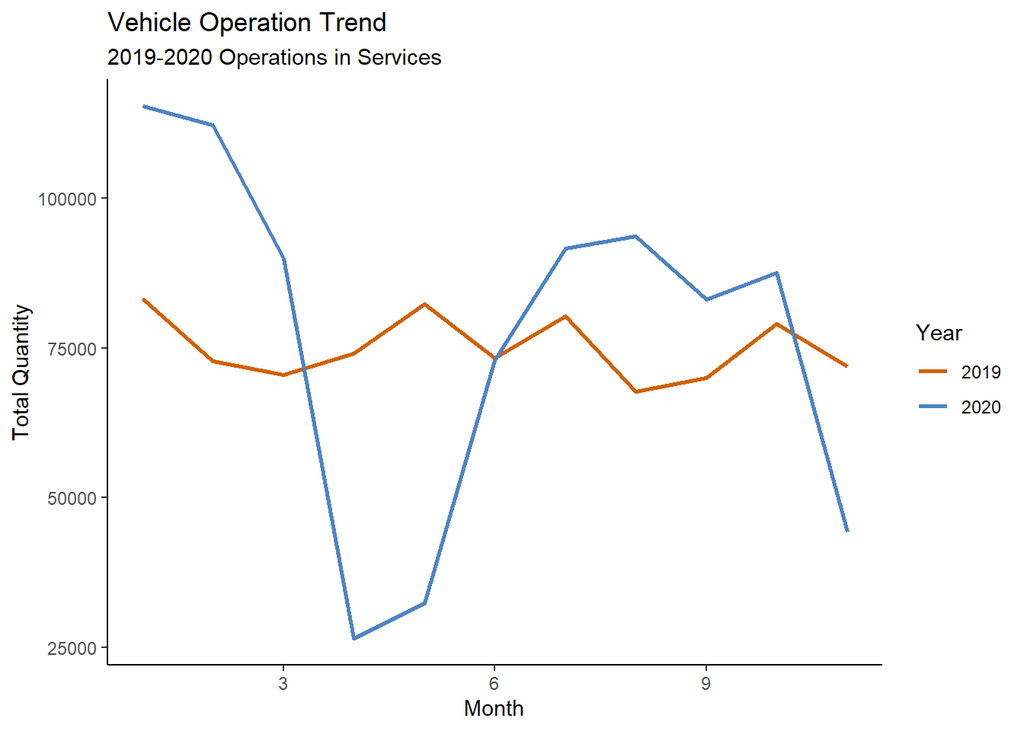

```r
dt_2019<- service_dt%>%
  group_by(month=lubridate::month(beginning_date),year=lubridate::year(beginning_date)) %>%
  filter(year == 2019) %>% summarise(total_quantity = sum(quantity))
graph_2019 <- dt_2019 %>% select(month,total_quantity)
dt_2020<- service_dt%>%
  group_by(month=lubridate::month(beginning_date),year=lubridate::year(beginning_date))%>%
  filter(year == 2020) %>% summarise(total_quantity = sum(quantity))
graph_2020 <- dt_2020 %>% select(month,total_quantity)
dt_graph = merge(graph_2019, graph_2020, by="month", )
dt_graph_2 <- reshape::melt(dt_graph, id.var='month')
p<-ggplot(dt_graph_2, aes(x=month, y=value, col=variable)) +geom_line(size=0.9) +
  ggtitle("Vehicle Operation Trend", "2019-2020 Operations in Services") +
  xlab("Month") + ylab("Total Quantity") + labs(color="Year") + theme_classic()
p + scale_color_manual(name="Year",
                      labels = c("2019", "2020"),
                      values = c("total_quantity.x"="#D16103",
                                 "total_quantity.y"="#4E84C4"))
```

## 2.2 Proportion of Process Types

```r
plot_1<- service_dt%>%
  mutate(count_total = n())%>%
  group_by(process_type)%>%
  mutate(count_vehicle_id = n())%>%
  select(process_type,count_vehicle_id, count_total)%>%
  mutate(rate_process_type = round(100*count_vehicle_id/count_total))%>%
  arrange(desc(rate_process_type))%>%
  distinct(process_type, rate_process_type)
print(plot_1)
```

```
## # A tibble: 11 x 2
## # Groups:   process_type [11]
##    process_type rate_process_type
##    <chr>                    <dbl>
##  1 Ariza                       84
##  2 P.Bakim                      6
##  3 Kontrol                      4
##  4 Hasar                        2
##  5 Kampanya                     2
##  6 Garanti                      2
##  7 Yol Yardım                   0
##  8 Dahili                       0
##  9 PDI                          0
## 10 Aksesuar                     0
## 11 P.Bak+Ariza                  0
```

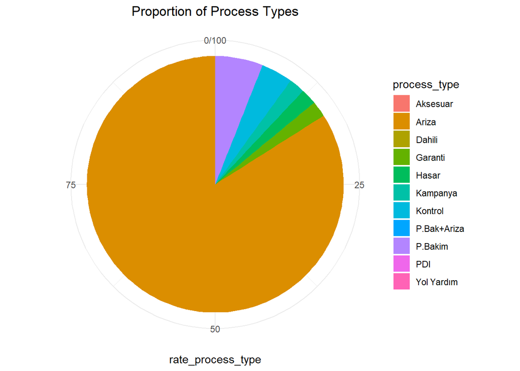

```r
ggplot(plot_1, aes(x="", y=rate_process_type, fill=process_type)) + geom_bar(stat="identity") +
  coord_polar("y") + ggtitle("Proportion of Process Types") +
  theme_minimal()+ theme(axis.title.y = element_blank(), plot.title = element_text(hjust=0.5))
```

## 2.3 The Expensive Types of Model

- Model 23 is the most expensive vehicle model, as it is the most frequently visited to the dealers.

```r
plot_7 <- eliminated %>%
  group_by(Model, production_date) %>%
  summarise(total_price = sum(price)) %>%
  mutate(age_of_car = as.numeric(format(Sys.Date(), "%Y"))-production_date)%>%
  arrange(desc(total_price))
plot_7
```

```
## # A tibble: 121 x 4
## # Groups:   Model [27]
##    Model    production_date total_price age_of_car
##    <chr>              <dbl>       <dbl>      <dbl>
##  1 model_23            2016   29279644.          4
##  2 model_1             2016   23435455.          4
##  3 model_23            2017   20997581.          3
##  4 model_21            2017   20108047.          3
##  5 model_21            2018   19286777.          2
##  6 model_9             2017   13556276.          3
##  7 model_21            2016   10950340.          4
##  8 model_9             2016   10451858.          4
##  9 model_2             2015    9139873.          5
## 10 model_27            2018    8599881.          2
## # ... with 111 more rows
```

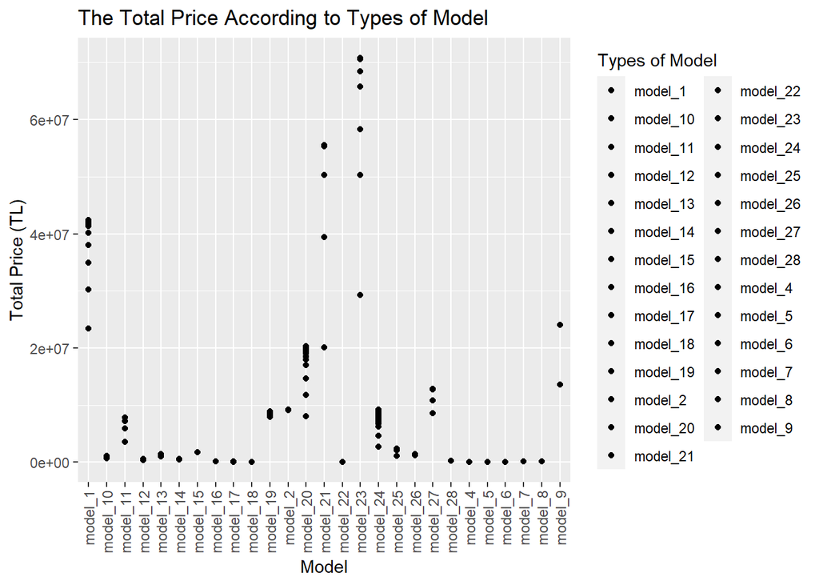

```r
ggplot(plot_7, aes(x = Model, y = total_price, fill= Model))+
  geom_point(stat="identity", position = "stack") +theme(axis.text.x = element_text(angle=90, size=9, vjust=0.5,hjust=1))+
  labs(x="Model", y="Total Price (TL)", fill ="Types of Model", title = "The Total Price According to Types of Model")
```

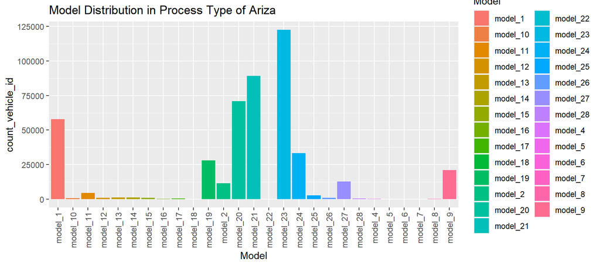

```r
plot_2<- service_dt%>%
  filter(process_type == "Ariza")%>%
  group_by(Model)%>%
  summarise(count_vehicle_id = n())%>%
  arrange(desc(Model))

ggplot(plot_2, aes(x = Model, y = count_vehicle_id, fill= Model))+ ggtitle("Model Distribution in Process Type of Ariza") +
  geom_bar(stat="identity") +theme(axis.text.x = element_text(angle=90, size=9, vjust=0.5,hjust=1))
```

## 2.4 The Usage Amount of The Material Types

- It was seen that the “diğer”, “parça” and “yag” materials were ranked in order of high to low, respectively, according to their usage amounts in whole process types.

```r
plot_5<- eliminated%>%
  group_by(process_type, material_type)%>%
  summarise(count = sum(quantity))%>%
  arrange(desc(count))
kable(plot_5,col.names = c("Process_Type", "Material_Type.", "Total_Quantity"))%>%
   kable_styling("striped", full_width = F) %>%
  scroll_box(width = "100%", height = "400px")
```

| Process_Type | Material_Type. | Total_Quantity |
| --- | --- | --- |
| Ariza | Diger | 901921.05 |
| Ariza | Parca | 354913.74 |
| Ariza | Yag | 129357.86 |
| P.Bakim | Diger | 62320.25 |
| Kontrol | Diger | 31813.03 |
| P.Bakim | Yag | 31086.40 |
| Kampanya | Diger | 23604.38 |
| Kontrol | Parca | 21885.75 |
| Hasar | Diger | 21093.68 |
| P.Bakim | Parca | 17463.55 |
| Kampanya | Yag | 12190.70 |
| Garanti | Diger | 11762.80 |
| Hasar | Parca | 9591.05 |
| Garanti | Parca | 9465.15 |
| Kampanya | Parca | 7367.61 |
| Kontrol | Yag | 6934.30 |
| Yol Yardım | Diger | 5783.45 |
| Dahili | Diger | 4585.10 |
| Yol Yardım | Parca | 3265.90 |
| Garanti | Yag | 1595.60 |
| Dahili | Parca | 617.00 |
| Yol Yardım | Yag | 467.60 |
| Aksesuar | Diger | 162.00 |
| Dahili | Yag | 110.50 |
| PDI | Diger | 68.00 |
| Ariza | Aksesuar | 61.00 |
| PDI | Parca | 38.00 |
| Hasar | Yag | 30.00 |
| PDI | Yag | 24.50 |
| Aksesuar | Parca | 13.00 |
| Kampanya | Aksesuar | 13.00 |
| P.Bak+Ariza | Yag | 9.50 |
| P.Bak+Ariza | Diger | 4.00 |
| P.Bak+Ariza | Parca | 3.00 |
| Kontrol | Aksesuar | 1.00 |
| P.Bakim | Aksesuar | 1.00 |

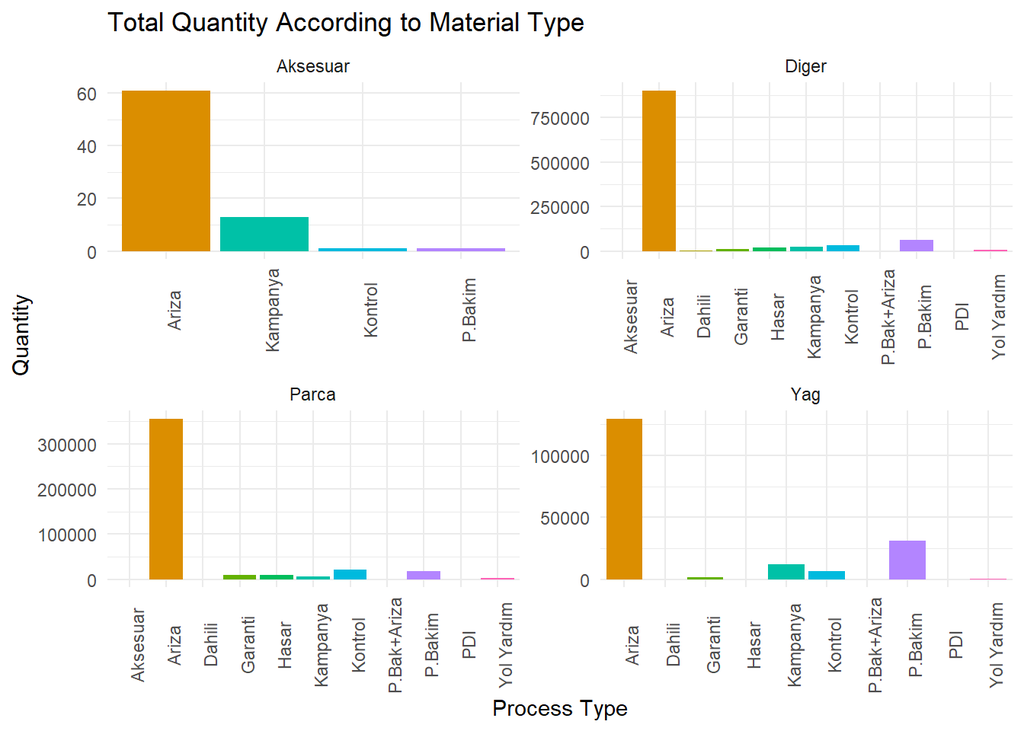

```r
  ggplot(plot_5, aes(y=count, x = process_type, fill = process_type)) +
  geom_col() +
  facet_wrap(~material_type, scales ="free") +
  theme_minimal() +
  theme(legend.position = "none") +
  scale_y_continuous(labels = function(x) format(x, scientific = FALSE)) +
  theme(axis.text.x = element_text(angle = 90), legend.position = "none")+
  labs(title = "Total Quantity According to Material Type ",
       x = "Process Type",
       y = "Quantity")
```

## 2.5 The Most Popular Dealers

- It was observed that the transactions were concentrated in the Marmara Region(Istanbul), where industry and transportation are intense, and in the Akdeniz and Ege regions(Antalya, İzmir), where tourism activities are intense.

```r
plot_6<- eliminated%>%
  count(dealer_city)%>%
  mutate(percentage = 100*round(n/sum(n),3))%>%
  arrange(desc(percentage))

kable(plot_6,col.names = c("Dealer_City", "Number of Process.", "Percentage"))%>%
kable_styling("striped", full_width = F) %>%
  scroll_box(width = "100%", height = "400px")
```

| Dealer_City | Number of Process. | Percentage |
| --- | --- | --- |
| İstanbul | 110758 | 20.8 |
| Antalya | 87578 | 16.4 |
| İzmir | 68052 | 12.8 |
| Ankara | 47843 | 9.0 |
| Kocaeli | 42691 | 8.0 |
| Bursa | 24345 | 4.6 |
| Denizli | 21804 | 4.1 |
| Gaziantep | 17282 | 3.2 |
| Erzurum | 15446 | 2.9 |
| Muğla | 14238 | 2.7 |
| Nevşehir | 10552 | 2.0 |
| Balıkesir | 9945 | 1.9 |
| Mersin | 9692 | 1.8 |
| Konya | 8719 | 1.6 |
| Sakarya | 6632 | 1.2 |
| Bolu | 5316 | 1.0 |
| Samsun | 4766 | 0.9 |
| Düzce | 3571 | 0.7 |
| Eskişehir | 3752 | 0.7 |
| Hatay | 3256 | 0.6 |
| Adıyaman | 2211 | 0.4 |
| Şanlıurfa | 1958 | 0.4 |
| Aksaray | 1761 | 0.3 |
| Aydın | 1586 | 0.3 |
| Uşak | 1729 | 0.3 |
| Çankırı | 1212 | 0.2 |
| Edirne | 1317 | 0.2 |
| Elazığ | 1274 | 0.2 |
| Karaman | 656 | 0.1 |
| Kayseri | 514 | 0.1 |
| Kütahya | 602 | 0.1 |
| Malatya | 420 | 0.1 |
| Sivas | 433 | 0.1 |
| Tekirdağ | 371 | 0.1 |
| Afyonkarahisar | 60 | 0.0 |
| Çorum | 260 | 0.0 |
| Diyarbakır | 33 | 0.0 |
| Kahramanmaraş | 6 | 0.0 |
| Niğde | 164 | 0.0 |
| Van | 249 | 0.0 |

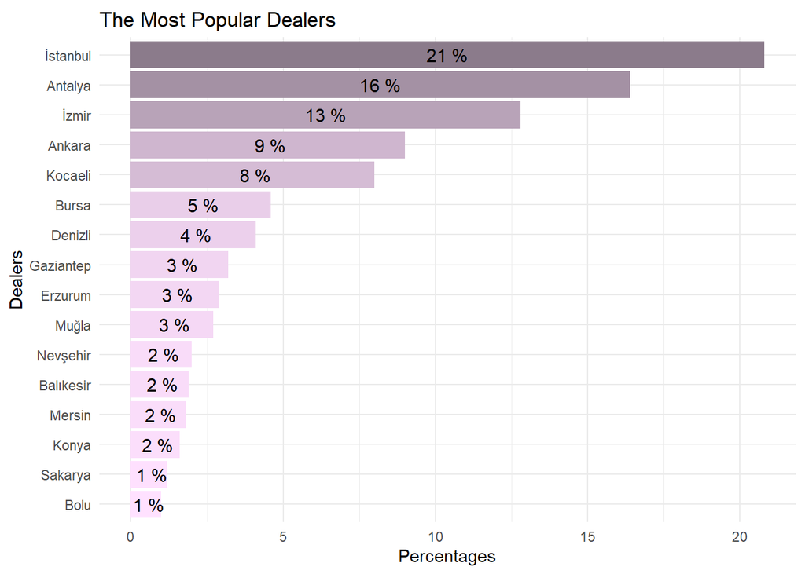

```r
plot_6%>%
  filter(percentage >= 1.0)%>%

ggplot(aes(x=percentage, y=reorder(dealer_city, percentage), fill=percentage)) +
  geom_col() +
  scale_fill_gradient("percentage", low="thistle1", high="thistle4") +
  geom_text(aes(label = paste(format(percentage,digits=1), "%")), size=4, position = position_stack(vjust = 0.5)) +
  theme_minimal() +
  theme(legend.position = "none", plot.title = element_text(vjust = 0.5)) +
  labs(x = "Percentages",
       y = "Dealers",
       title = "The Most Popular Dealers")
```